# Rapport

## 3.2 Analyses multivariées

### 3.2.1 Choix des axes

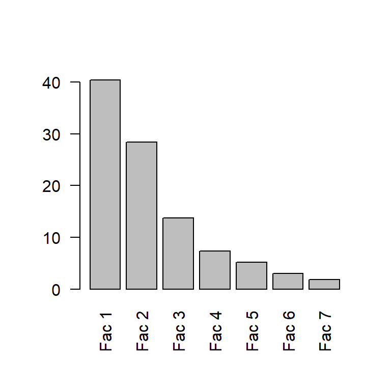

Fig 3 : Intertie

```r
caphos <- CA(phos, graph=FALSE)
## Valeurs propres
barplot(caphos$eig[,2], names.arg = paste("Fac",1:7), las=2 )
```

L’axe 1 explique 40.42% de l’inertie et l’axe 2 en explique 28.4%.

### 3.2.2 Axes et Graphiques

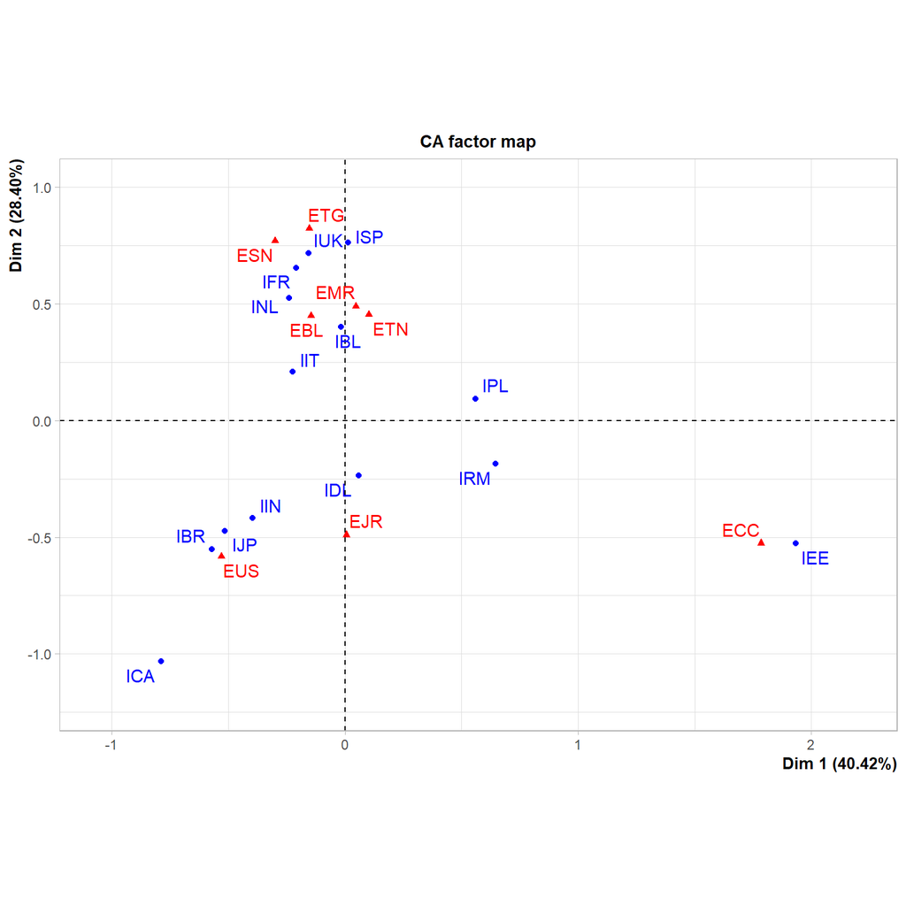

Fig 4 : Axes

```r
plot.CA(caphos)
```

```r
ctrc <- caphos$col$contrib
ctrl <- caphos$row$contrib
```

## 3.3 Classification

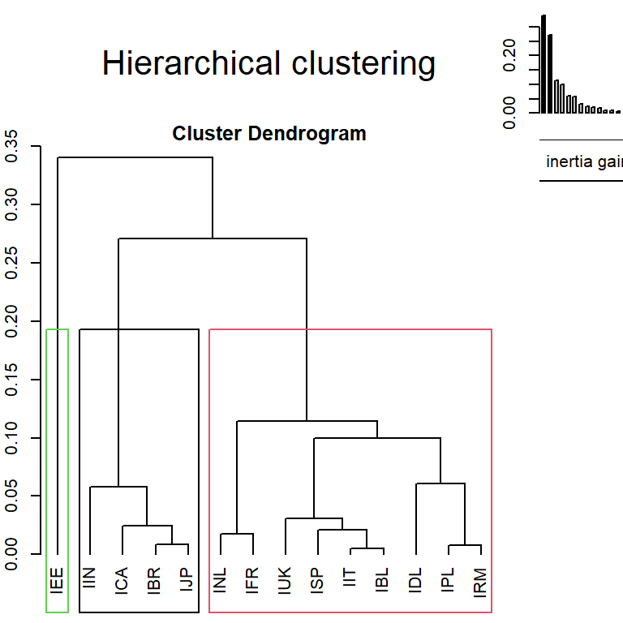

Fig 5: Arbre

```r
cahp <- HCPC(caphos, graph=FALSE)
plot.HCPC(cahp, choice="tree")
```

```r
lapply(cahp$desc.var, function(x) return(x[x[, 6]>0, ]))
```

```
## $`1`
##      Intern %    glob % Intern freq Glob freq  p.value v.test
## EJR  5.665519  2.722962       15634      27270       0    Inf
## EUS 75.490487 35.558866      208316     356116       0    Inf
##
## $`2`
##      Intern %    glob % Intern freq Glob freq  p.value v.test
## ETN  5.438796  4.238714       35218      42450       0    Inf
## ETG  9.209415  6.061012       59634      60700       0    Inf
## ESN  4.875427  3.633811       31570      36392       0    Inf
## EMR 43.483035 33.745855      281567     337959       0    Inf
## EBL  4.923301  3.210439       31880      32152       0    Inf
##
## $`3`
##     Intern %    glob % Intern freq Glob freq     p.value   v.test
## ECC     72.8 10.828342       56784     108444 0.00000000      Inf
## ETN      4.4  4.238714        3432      42450 0.02095465 2.308801
```

Nous pouvons identifier 3 groupes :

[output not shown]

# 4 Interpretations et Conclusion

# 5 Références

## 5.2 Bibliographie

Liste des publications :

GERLAGH, Reyer, LUPI, Veronica et GALEOTTI, Marzio, 2018. Family Planning and Climate Change. 2018.

LACROIX, Karine, 2018. Comparing the relative mitigation potential of individual pro-environmental behaviors. *Journal of cleaner production*. 2018. Vol. 195, pp. 1398‑1407.

STERN, Paul C et WOLSKE, Kimberly S, 2017. Limiting climate change: what’s most worth doing? *Environmental Research Letters*. 2017. Vol. 12, n° 9, pp. 091001.

WYNES, Seth et NICHOLAS, Kimberly A, 2017. The climate mitigation gap: education and government recommendations miss the most effective individual actions. *Environmental Research Letters*. 2017. Vol. 12, n° 7, pp. 074024.